# Introduction to R for Biologists

BIOL 4994/BIOL 4991 undegrads BIOL 6994/BIOL 6997 grads

Alan J. Figueroa Ruiz

2025-Dec-16, 04:33 PM

# Examen 2

# Exam 2

```r
library(ggplot2)
library(dplyr)
library(palmerpenguins)
data(package = 'palmerpenguins')
head(penguins)
```

```
## # A tibble: 6 × 8
##   species island    bill_length_mm bill_depth_mm flipper_length_mm body_mass_g
##   <fct>   <fct>              <dbl>         <dbl>             <int>       <int>
## 1 Adelie  Torgersen           39.1          18.7               181        3750
## 2 Adelie  Torgersen           39.5          17.4               186        3800
## 3 Adelie  Torgersen           40.3          18                 195        3250
## 4 Adelie  Torgersen           NA            NA                  NA          NA
## 5 Adelie  Torgersen           36.7          19.3               193        3450
## 6 Adelie  Torgersen           39.3          20.6               190        3650
## # ℹ 2 more variables: sex <fct>, year <int>
```

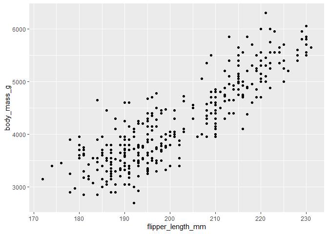

```r
ggplot(data = penguins,
       aes(
         x = flipper_length_mm,
         y = body_mass_g)
       ) +
  geom_point()
```

2. Starting from the previous plot and using similar code, modify the scatterplot to color the points by species. Partiendo del gráfico anterior y usando un código similar, modifica el gráfico de dispersión para colorear los puntos por species.

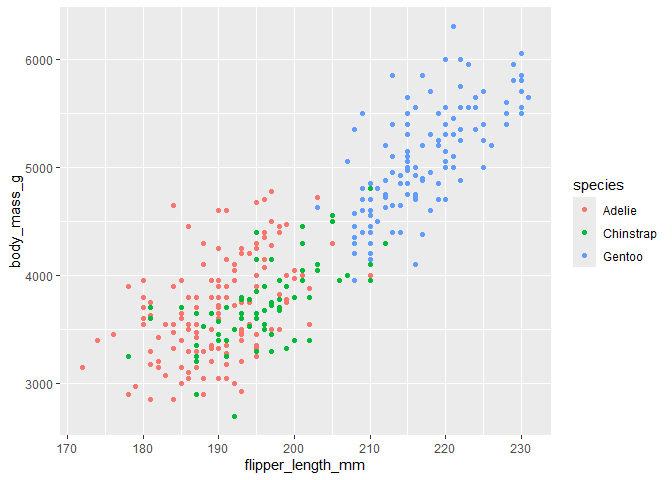

```r
ggplot(data = penguins,
       aes(x = flipper_length_mm,
           y = body_mass_g,
           color = species)
       ) +
  geom_point()
```

3. Starting from the previous plot and using similar code, modify the scatterplot to facet the data by species. Partiendo del gráfico anterior y usando un código similar, modifica el gráfico de dispersión para crear paneles separados por species.

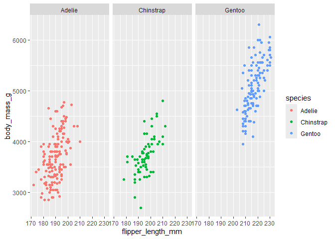

```r
ggplot(data = penguins,
       aes(x = flipper_length_mm,
           y = body_mass_g,
           color = species)
       ) +
  geom_point() +
  facet_wrap(~ species)
```

4. Starting from the previous plot and using similar code, add a smooth line for each species. Partiendo del gráfico anterior y usando un código similar, añade una línea de suavizado para cada especie.

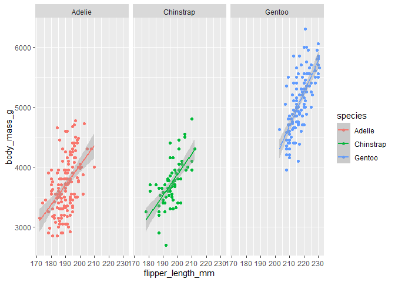

```r
ggplot(data = penguins,
       mapping = aes(x = flipper_length_mm,
                     y = body_mass_g,
                     color = species)
       ) +
  geom_point() +
  facet_wrap(~ species) +
  geom_smooth(method = "lm")
```

5. Starting from the plot you created in Question 1, modify it to make it “publication-ready” by improving at least three aspects. Partiendo del gráfico que creaste en la Pregunta 1, modifícalo para que sea apto para publicación mejorando al menos tres aspectos.

Aspectos cambiados: 1- Etiquetas de los ejes y Título del Gráfico 2- Tema de Fondo Blanco 3- Aspectos estéticos del gráfico (título, ejes y texto) - BOLD y Tamaño

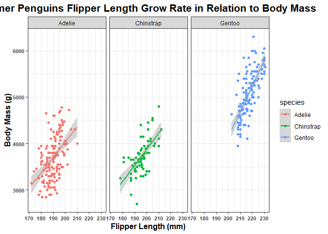

```r
ggplot(data = penguins,
       mapping = aes(x = flipper_length_mm,
                     y = body_mass_g,
                     color = species)
       ) +
  geom_point() +
  facet_wrap(~ species) +
  geom_smooth(method = "lm") +
  # Etiquetas de los ejes y el título del gráfico
  labs(x = "Flipper Length (mm)",
       y = "Body Mass (g)",
       title = "Palmer Penguins Flipper Length Grow Rate in Relation to Body Mass"
              ) +
        # Tema de fondo blanco
         theme_bw() +
        # Aspectos estéticos del gráfico (título, ejes y texto)
         theme(
           plot.title = element_text(hjust = 0.5, size = 16, face = "bold"),
           axis.title = element_text(size = 12, face = "bold"),
           axis.text  = element_text(size = 8, face = "bold")
         )
```

Questions / Preguntas (4 pts each / 4 pts cada una) - Important: - Provide only the numerical values exactly as they appear in the model output (including decimals or scientific notation). Importante: - Provee únicamente los valores numéricos exactamente como aparecen en el output del modelo (incluyendo decimales o notación exponencial).

1. What is the R-squared value of the model? ¿Cuál es el valor de R-cuadrado del modelo?

2. What is the p-value for the slope coefficient? ¿Cuál es el p-valor del coeficiente de la pendiente?

3. Based on the p-value, is there a relationship between flipper length and body mass? Basado en el p-valor, ¿hay una relación entre longitud de aletas y masa corporal?

4. What is the intercept? ¿Cuál es el intercepto?

5. What is the slope? ¿Cuál es la pendiente?